# Basic initial univariate descriptive statistics of raw variables

Team 2 Group 11

This is a study of the different variables focused on searching null, incorrect and outlier values. After the preprocessing we will make a larger analysis trying to find the characteristics for each variable.

```r
if(!require("ggplot2"))install.packages("ggplot2", repos = "http://cran.us.r-project.org"); require("ggplot2")
if(!require("e1071"))install.packages("e1071", repos = "http://cran.us.r-project.org"); require("e1071")
if(!require("readr"))install.packages("readr"); require("readr")
```

### 1. Loading the dataset

```r
Terrorism_US_FIXED <- read_csv("Terrorism_US_FIXED.csv")
colnames(Terrorism_US_FIXED)
```

```
 [1] "X1"                   "provstate"            "city"
 [4] "latitude"             "longitude"            "doubtterr"
 [7] "success"              "attacktype1_txt"      "targtype1_txt"
[10] "natlty1_txt"          "gname"                "nperps"
[13] "nperpcap"             "claimed"              "claimmode_txt"
[16] "weaptype1_txt"        "nkill"                "nkillus"
[19] "nkillter"             "nwound"               "nwoundus"
[22] "nwoundte"             "propvalue"            "INT_IDEO"
[25] "INT_MISC"             "president_party"      "state_governor_party"
[28] "date"
```

### 2. Study of each variable

#### 2.1. Variable provstate

```r
summary(as.factor(Terrorism_US_FIXED$provstate))
```

```
             Alabama               Alaska              Arizona
                  16                    1                   34
            Arkansas           California             Colorado
                   5                  595                   45
         Connecticut             Delaware District of Columbia
                  17                    3                   83
             Florida              Georgia               Hawaii
                 158                   29                    4
               Idaho             Illinois              Indiana
                  14                  112                   22
                Iowa               Kansas             Kentucky
                  24                   14                    4
           Louisiana                Maine             Maryland
                  22                    4                   35
       Massachusetts             Michigan            Minnesota
                  57                   45                   25
         Mississippi             Missouri              Montana
                  11                   39                    6
            Nebraska               Nevada        New Hampshire
                  24                   18                   10
          New Jersey           New Mexico             New York
                  47                   24                  515
      North Carolina         North Dakota                 Ohio
                  34                    6                   51
            Oklahoma               Oregon         Pennsylvania
                  15                   67                   33
         Puerto Rico         Rhode Island       South Carolina
                 248                    2                    5
        South Dakota            Tennessee                Texas
                   9                   24                   63
 U.S. Virgin Islands              Unknown                 Utah
                   3                    1                   20
             Vermont             Virginia           Washington
                   5                   42                  101
       West Virginia            Wisconsin              Wyoming
                   2                   37                    2
                NA's
                   4
```

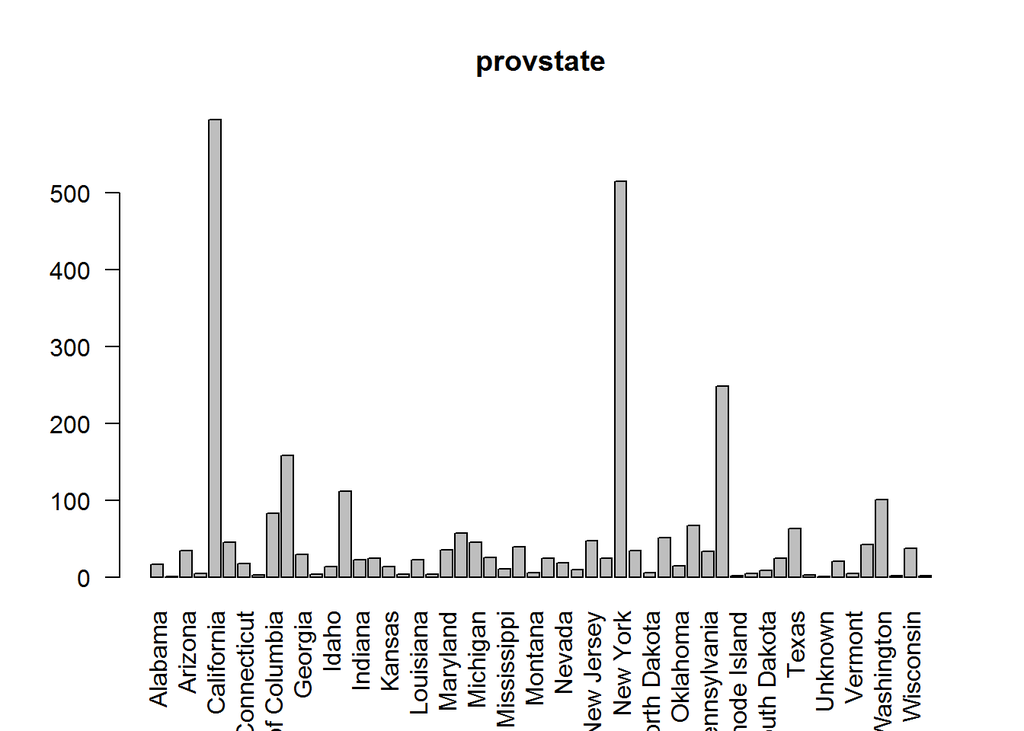

```r
barplot(table(Terrorism_US_FIXED$provstate),main="provstate",las=2)
```

#### 2.2. Variable city

```r
summary(as.factor(Terrorism_US_FIXED$city))
```

```
   New York City         San Juan      Los Angeles    San Francisco
             460              116              109               98
           Miami       Washington          Chicago          Seattle
              85               85               57               39
        Berkeley           Denver         Portland        San Diego
              33               23               22               22
         Oakland      Kansas City           Boston          Houston
              20               19               18               18
        San Jose      Rio Piedras       Sacramento      Albuquerque
              18               17               16               15
         Detroit          Unknown          Phoenix           Fresno
              15               15               14               13
       Arlington          Atlanta            Cairo         Carolina
              12               12               12               12
        Columbus           Eugene      Baton Rouge        Cambridge
              12               12               11               11
       Palo Alto      Bloomington           Caguas       Cincinnati
              11               10               10               10
    Philadelphia            Tampa          Boulder            Chico
              10               10                9                9
       Milwaukee            Ponce        San Bruno         St. Paul
               9                9                9                9
         Bayamon        Champaign        Cleveland           Dallas
               8                8                8                8
         Madison       Santa Cruz         Bellevue      Chattanooga
               8                8                7                7
    Fayetteville          Jackson        Las Vegas      New Orleans
               7                7                7                7
         Olympia           Oxford   Salt Lake City South Sioux City
               7                7                7                7
       St. Louis   St. Petersburg            Akron        Ann Arbor
               7                7                6                6
      Des Moines     East Lansing          Everett          Hoboken
               6                6                6                6
      Long Beach         Mayaguez      Minneapolis           Newark
               6                6                6                6
         Norfolk        Pensacola          Redding          Spokane
               6                6                6                6
          Toledo            Trona            Tulsa       Union City
               6                6                6                6
          Auburn           Austin        Baltimore        Charlotte
               5                5                5                5
   Coeur D'Alene Colorado Springs          Concord        Elizabeth
               5                5                5                5
    Falls Church       Greensboro     Indianapolis     Jacksonville
               5                5                5                5
      Manchester        Nashville         Petaluma       Pittsburgh
               5                5                5                5
            Reno         Rockford      San Antonio          (Other)
               5                5                5              945
```

Since city is a textual variable we will not do a plot (because there are lots of them).

#### 2.3. Variable latitude

```r
summary(Terrorism_US_FIXED$latitude)
```

```
    Min.  1st Qu.   Median     Mean  3rd Qu.     Max.     NA's
   17.97    34.10    38.91   126.77    40.70 40616.00        1
```

```r
skewness(Terrorism_US_FIXED$latitude,na.rm = TRUE)
```

```
[1] 20.12585
```

```r
kurtosis(Terrorism_US_FIXED$latitude,na.rm = TRUE)
```

```
[1] 404.429
```

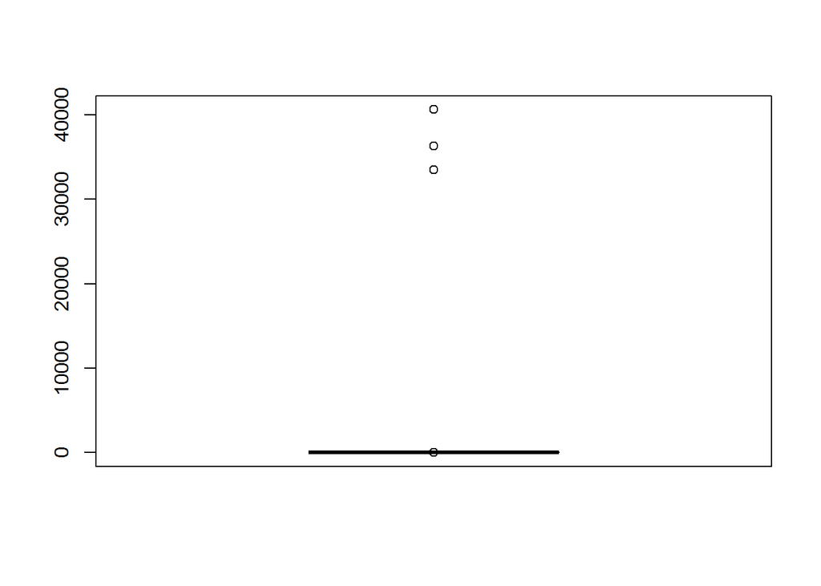

```r
boxplot(Terrorism_US_FIXED$latitude)
```

Since at this point in time the preprocessing is still not done, the summary, the skewness and the kurtosis do not make much sense since there are incorrect values.

#### 2.4. Variable longitude

```r
summary(Terrorism_US_FIXED$longitude)
```

```
     Min.   1st Qu.    Median      Mean   3rd Qu.      Max.      NA's
-66266.00   -117.81    -84.51   -115.17    -73.93    105.27         1
```

```r
skewness(Terrorism_US_FIXED$longitude,na.rm = TRUE)
```

```
[1] -53.16391
```

```r
kurtosis(Terrorism_US_FIXED$longitude,na.rm = TRUE)
```

```
[1] 2826.267
```

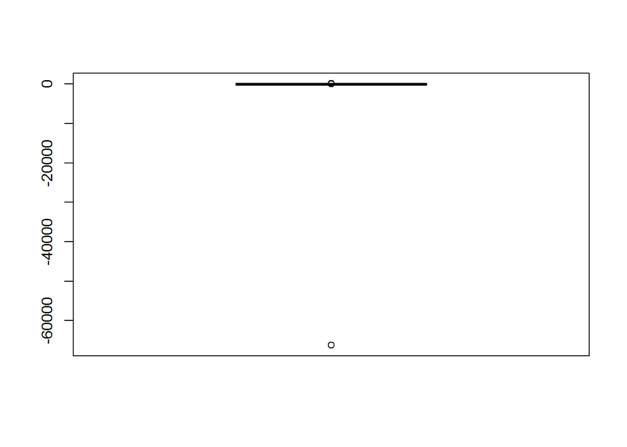

```r
boxplot(Terrorism_US_FIXED$longitude)
```

In the same way as with the latitude, the information above should not be considered truly valid.

#### 2.5. Variable doubtterr

```r
summary(as.logical(Terrorism_US_FIXED$doubtterr))
```

```
   Mode   FALSE    TRUE
logical    2276     560
```

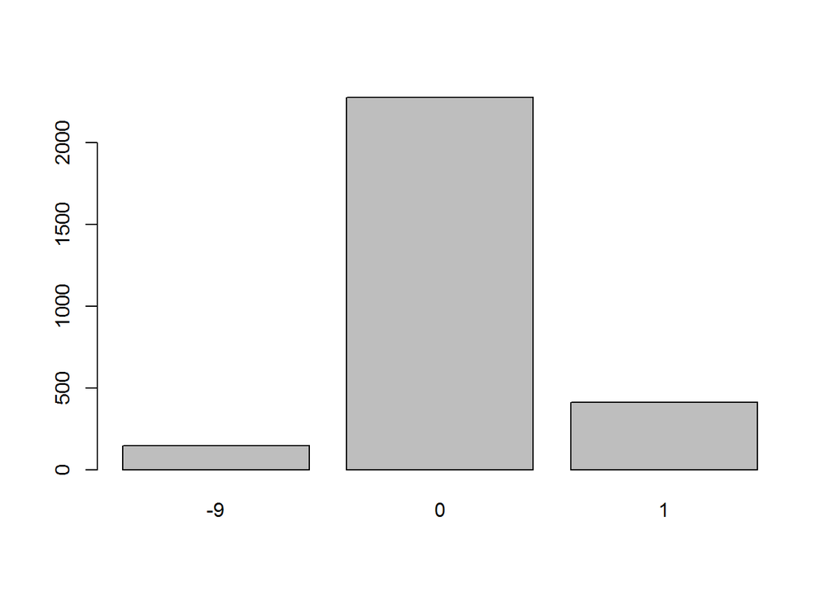

```r
barplot(table(Terrorism_US_FIXED$doubtterr))
```

Since the missings in this variable are ‘-9’, R interpretes them as true because they are different than 0, so the summary does not count the number of trues correctly.

#### 2.6. Variable success

```r
summary(as.logical(Terrorism_US_FIXED$success))
```

```
   Mode   FALSE    TRUE
logical     500    2336
```

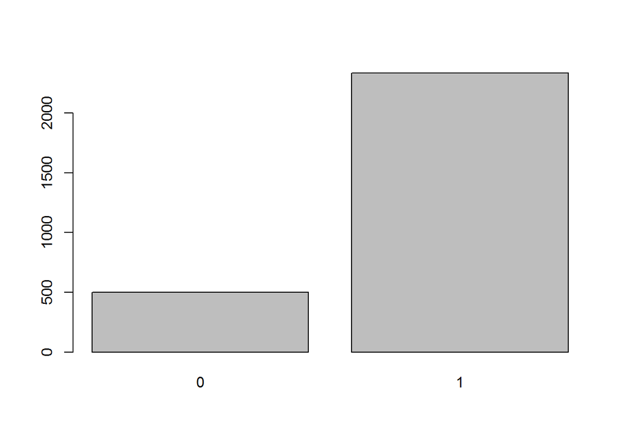

```r
barplot(table(Terrorism_US_FIXED$success))
```

Here we can see a variable that is correct despite not being preprocessed. We can see that the majority of the attacks are successful.

#### 2.7. Variable attacktype1_txt

```r
summary(as.factor(Terrorism_US_FIXED$attacktype1_txt))
```

```
                                  0                       Armed Assault
                                  9                                 281
                      Assassination                   Bombing/Explosion
                                132                                1382
     Facility/Infrastructure Attack                           Hijacking
                                862                                  17
Hostage Taking (Barricade Incident)         Hostage Taking (Kidnapping)
                                 62                                  20
                    Unarmed Assault                             Unknown
                                 60                                  11
```

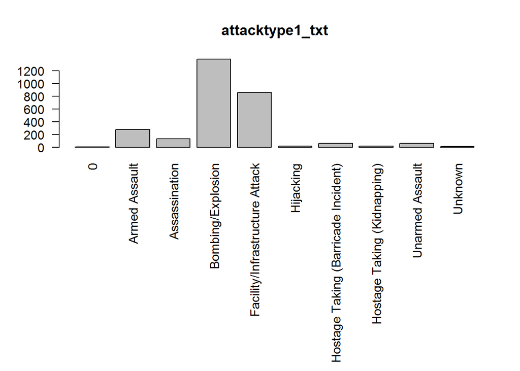

```r
op <- par(mar=c(15,4,4,2))
barplot(table(Terrorism_US_FIXED$attacktype1_txt),main="attacktype1_txt",las=2)
```

```r
rm(op)
```

Thanks to the summary and the barplot, we can observe that there are missings specified with ‘0’ and with ‘Unknown’.

#### 2.8. Variable targtype1_txt

```r
summary(as.factor(Terrorism_US_FIXED$targtype1_txt))
```

```
              Abortion Related            Airports & Aircraft
                           253                             53
                      Business        Educational Institution
                           780                            169
          Food or Water Supply        Government (Diplomatic)
                             7                            148
          Government (General)            Journalists & Media
                           327                             60
                      Maritime                       Military
                             7                            187
                           NGO                          Other
                            28                              2
                        Police    Private Citizens & Property
                           170                            340
Religious Figures/Institutions              Telecommunication
                           147                             10
  Terrorists/Non-State Militia                       Tourists
                             8                              9
                Transportation                        Unknown
                            17                             11
                     Utilities        Violent Political Party
                            88                              6
                          NA's
                             9
```

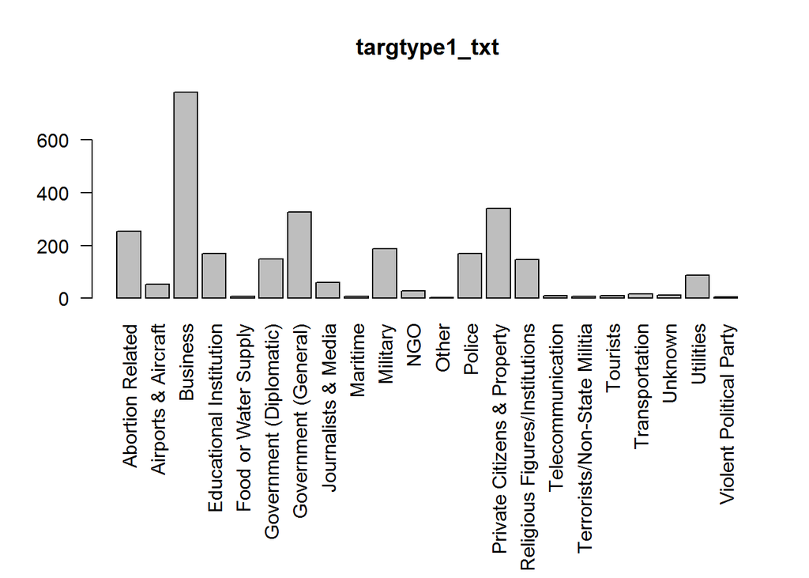

```r
op <- par(mar=c(12,4,4,2))
barplot(table(Terrorism_US_FIXED$targtype1_txt),main="targtype1_txt",las=2)
```

```r
rm(op)
```

We can see that the most targeted type is business. We can also see that there are null values as Unknown.

#### 2.9. Variable natlty1_txt

```r
summary(as.factor(Terrorism_US_FIXED$natlty1_txt))
```

```
                                                                                           Angola
                                                                                                1
                                                                                        Argentina
                                                                                                1
                                                                                          Bahamas
                                                                                                2
                                                                                       Bangladesh
                                                                                                1
                                                                                           Branch
                                                                                                1
                                                                                           Brazil
                                                                                                1
                                                                                           Canada
                                                                                                1
                                                                                            Chile
                                                                                                1
                                                                                            China
                                                                                                4
                                                                                           Church
                                                                                                1
                                                                                         Colombia
                                                                                                2
                                                                                       Costa Rica
                                                                                                2
                                                                                          Croatia
                                                                                                3
                                                                                             Cuba
                                                                                               24
                                                                                   Czechoslovakia
                                                                                                1
                                                                 Democratic Republic of the Congo
                                                                                                1
                                                                               Dominican Republic
                                                                                                5
                                                                                            Egypt
                                                                                                9
                                                                                           France
                                                                                                2
                                                                                          Germany
                                                                                                1
```

[output cut: 87 more lines]

```
                                                                                                8
                                                                                          Vietnam
                                                                                                9
                                                                            Virgin Islands (U.S.)
                                                                                                3
                                                                         West Bank and Gaza Strip
                                                                                                5
                                                                               West Germany (FRG)
                                                                                                1
William Long and Quinton I. Ezeagwula, soldiers who were outside of a military recruiting station
                                                                                                1
                                                                                       Yugoslavia
                                                                                               11
                                                                                             NA's
                                                                                                9
```

Thanks to this summary we can see that there are values that do not make sense as a nationality like “Journalist: Kurt Eichenwald”.

#### 2.10. Variable gname

```r
summary(as.factor(Terrorism_US_FIXED$gname))
```

```
                                                    Unknown
                                                        572
                                   Anti-Abortion extremists
                                                        196
                                        Left-Wing Militants
                                                        169
              Fuerzas Armadas de Liberacion Nacional (FALN)
                                                        120
                                           White extremists
                                                         87
                          New World Liberation Front (NWLF)
                                                         86
                                         Black Nationalists
                                                         83
                              Animal Liberation Front (ALF)
                                                         76
                                Jewish Defense League (JDL)
                                                         74
                                           Student Radicals
                                                         71
                               Earth Liberation Front (ELF)
                                                         66
                                                    Omega-7
                                                         54
                            Weather Underground, Weathermen
                                                         45
                                                 Macheteros
                                                         37
                                      Black Liberation Army
                                                         36
                                 Anti-Government extremists
                                                         35
                                   Chicano Liberation Front
                                                         31
           Armed Revolutionary Independence Movement (MIRA)
                                                         30
                                 United Freedom Front (UFF)
                                                         29
                                     Anti-Muslim extremists
                                                         27
```

[output cut: 145 more lines]

```
                                                          3
                                          Anti-Castro Group
                                                          3
                                Anti-Gun Control extremists
                                                          3
                  Armed Forces of Popular Resistance (FARP)
                                                          3
                           Black Revolutionary Assault Team
                                                          3
                                               Earth First!
                                                          3
                                                    (Other)
                                                        197
                                                       NA's
                                                          8
```

#### 2.11. Variable nperps

```r
summary(Terrorism_US_FIXED$nperps)
```

```
   Min. 1st Qu.  Median    Mean 3rd Qu.    Max.    NA's
 -99.00  -99.00  -99.00  -53.66    1.00  400.00     982
```

```r
skewness(Terrorism_US_FIXED$nperps,na.rm = TRUE)
```

```
[1] 0.6139484
```

```r
kurtosis(Terrorism_US_FIXED$nperps,na.rm = TRUE)
```

```
[1] 1.457389
```

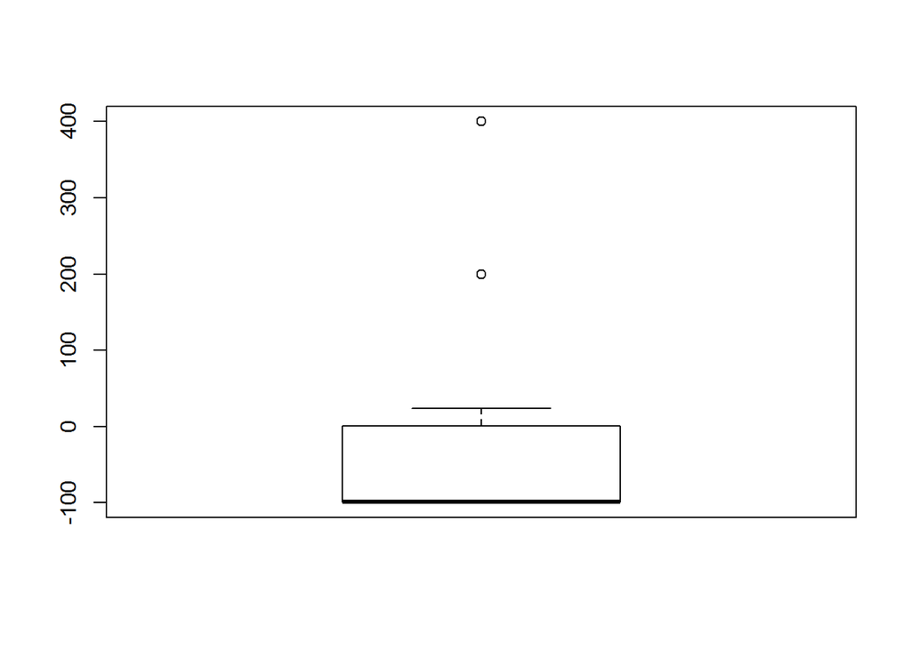

```r
boxplot(Terrorism_US_FIXED$nperps)
```

Here the missings are marked with ‘-99’ so not all data is valid, with the preprocessing we will fix this.

#### 2.12. Variable npercap

```r
summary(Terrorism_US_FIXED$nperpcap)
```

```
   Min. 1st Qu.  Median    Mean 3rd Qu.    Max.    NA's
 -99.00  -99.00  -99.00  -52.93    1.00   11.00    1054
```

```r
skewness(Terrorism_US_FIXED$nperpcap,na.rm = TRUE)
```

```
[1] 0.1632706
```

```r
kurtosis(Terrorism_US_FIXED$nperpcap,na.rm = TRUE)
```

```
[1] -1.972689
```

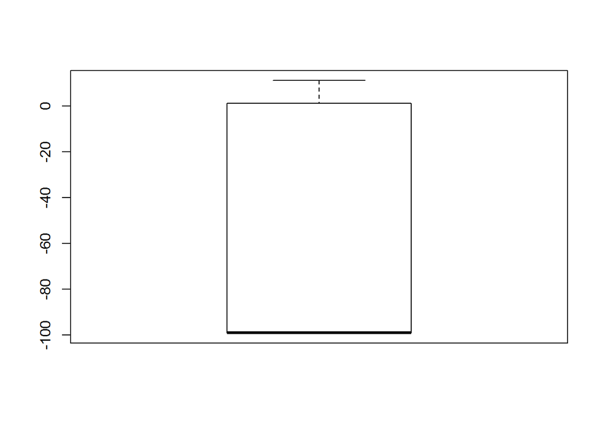

```r
boxplot(Terrorism_US_FIXED$nperpcap)
```

Here’s happening the same thing as before, so we cannot extract conclusions from this.

#### 2.13. Variable claimed

```r
summary(as.logical(Terrorism_US_FIXED$claimed))
```

```
   Mode   FALSE    TRUE    NA's
logical    1221     565    1050
```

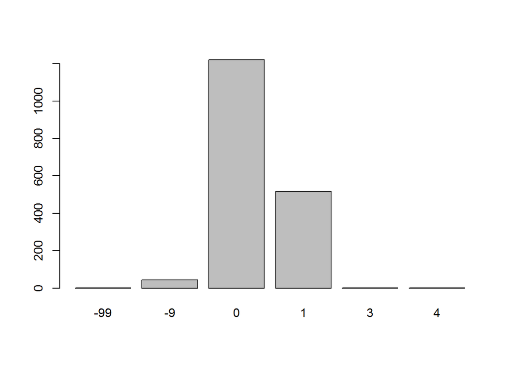

```r
barplot(table(Terrorism_US_FIXED$claimed))
```

Thanks to this we see that for some reason, despite being a logical variable, there are many different values. During the preprocessing we will study this.

#### 2.14. Variable claimmode_txt

```r
summary(as.factor(Terrorism_US_FIXED$claimmode_txt))
```

```
                            0                             1
                            5                             8
         Call (post-incident)           Call (pre-incident)
                           82                            11
                       E-mail                        Letter
                            9                           105
           Note left at scene                         Other
                           71                            52
               Personal claim Posted to website, blog, etc.
                          105                            32
                      Unknown                         Video
                           44                             4
                         NA's
                         2308
```

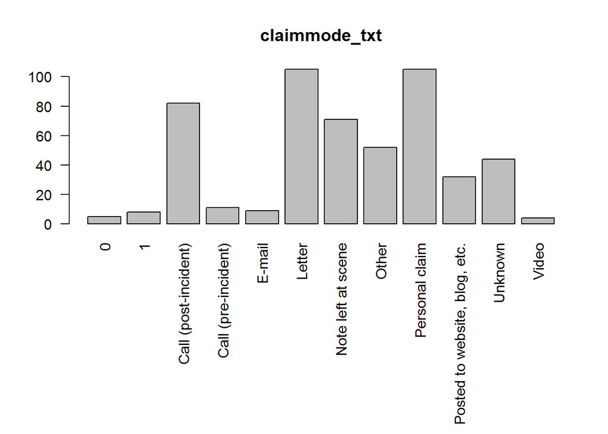

```r
op <- par(mar=c(12,4,4,2))
barplot(table(Terrorism_US_FIXED$claimmode_txt),main="claimmode_txt",las=2)
```

```r
rm(op)
```

Here we see that there are some ‘0’, ‘1’ and ‘Unknown’ that shold be NA.

#### 2.15. Variable weaptype1_txt

```r
summary(as.factor(Terrorism_US_FIXED$weaptype1_txt))
```

```
                                                                          0
                                                                          4
                                                                 Biological
                                                                         24
                                                                   Chemical
                                                                         22
                                                                 Explosives
                                                                       1402
                                                               Fake Weapons
                                                                          4
                                                                   Firearms
                                                                        400
                                                                 Incendiary
                                                                        844
                                                                      Melee
                                                                         43
                                                                      Other
                                                                         16
                                                               Radiological
                                                                          1
                                                         Sabotage Equipment
                                                                         18
                                                                    Unknown
                                                                         39
Vehicle (not to include vehicle-borne explosives, i.e., car or truck bombs)
                                                                         10
                                                                       NA's
                                                                          9
```

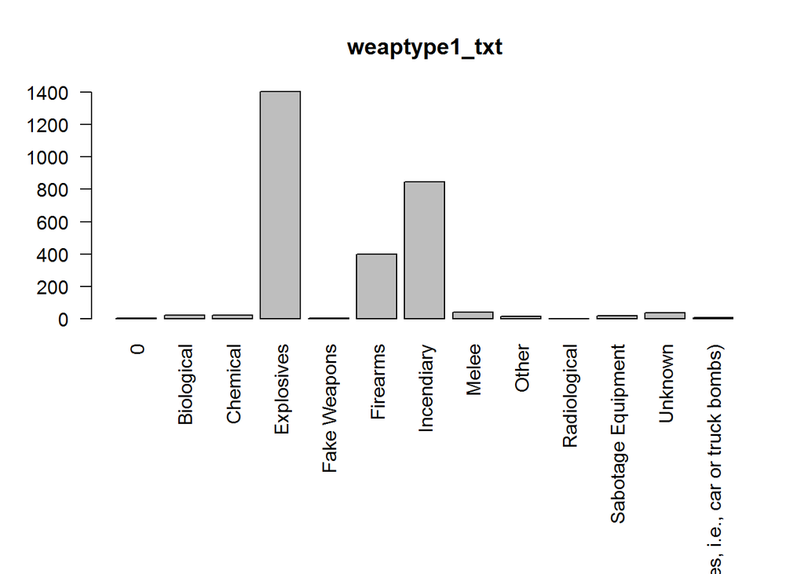

```r
op <- par(mar=c(11,4,4,2))
barplot(table(Terrorism_US_FIXED$weaptype1_txt),main="weaptype1_txt",las=2)
```

```r
rm(op)
```

Here we see that there are some Unknown that shold be treated as NA and that Vehicle (not to include vehicle-borne explosives, i.e., car or truck bombs) has a very long name so in the preprocessing we should just put vehicle so it can be shown in the plot.

#### 2.16. Variable nkill

```r
summary(as.numeric(Terrorism_US_FIXED$nkill))
```

```
    Min.  1st Qu.   Median     Mean  3rd Qu.     Max.     NA's
   0.000    0.000    0.000    1.366    0.000 1384.000       86
```

```r
skewness(as.numeric(Terrorism_US_FIXED$nkill,na.rm = TRUE))
```

```
[1] NA
```

```r
kurtosis(as.numeric(Terrorism_US_FIXED$nkill,na.rm = TRUE))
```

```
[1] NA
```

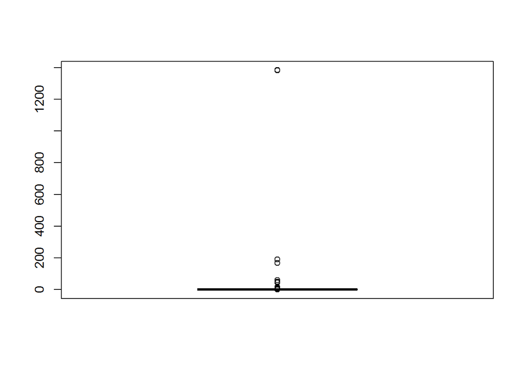

```r
boxplot(as.numeric(Terrorism_US_FIXED$nkill))
```

Here we see that nkill was imported as a character variable and so we have to do as.numeric() to even do the boxplot, but it does not work properly and the skewness and kurtosis were not properly calculated.

#### 2.17. Variable nkillus

```r
summary(Terrorism_US_FIXED$nkillus)
```

```
    Min.  1st Qu.   Median     Mean  3rd Qu.     Max.     NA's
   0.000    0.000    0.000    1.857    0.000 1360.000      953
```

```r
skewness(Terrorism_US_FIXED$nkillus,na.rm = TRUE)
```

```
[1] 29.85803
```

```r
kurtosis(Terrorism_US_FIXED$nkillus,na.rm = TRUE)
```

```
[1] 902.7565
```

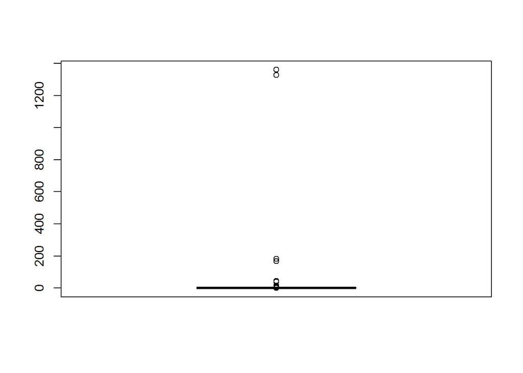

```r
boxplot(Terrorism_US_FIXED$nkillus)
```

Thanks to this we can see some possible outliers that should be studied during the preprocessing.

#### 2.19. Variable nkiller

```r
summary(Terrorism_US_FIXED$nkillter)
```

```
   Min. 1st Qu.  Median    Mean 3rd Qu.    Max.    NA's
 0.0000  0.0000  0.0000  0.0415  0.0000  5.0000    1003
```

```r
skewness(Terrorism_US_FIXED$nkillter,na.rm = TRUE)
```

```
[1] 10.77951
```

```r
kurtosis(Terrorism_US_FIXED$nkillter,na.rm = TRUE)
```

```
[1] 144.621
```

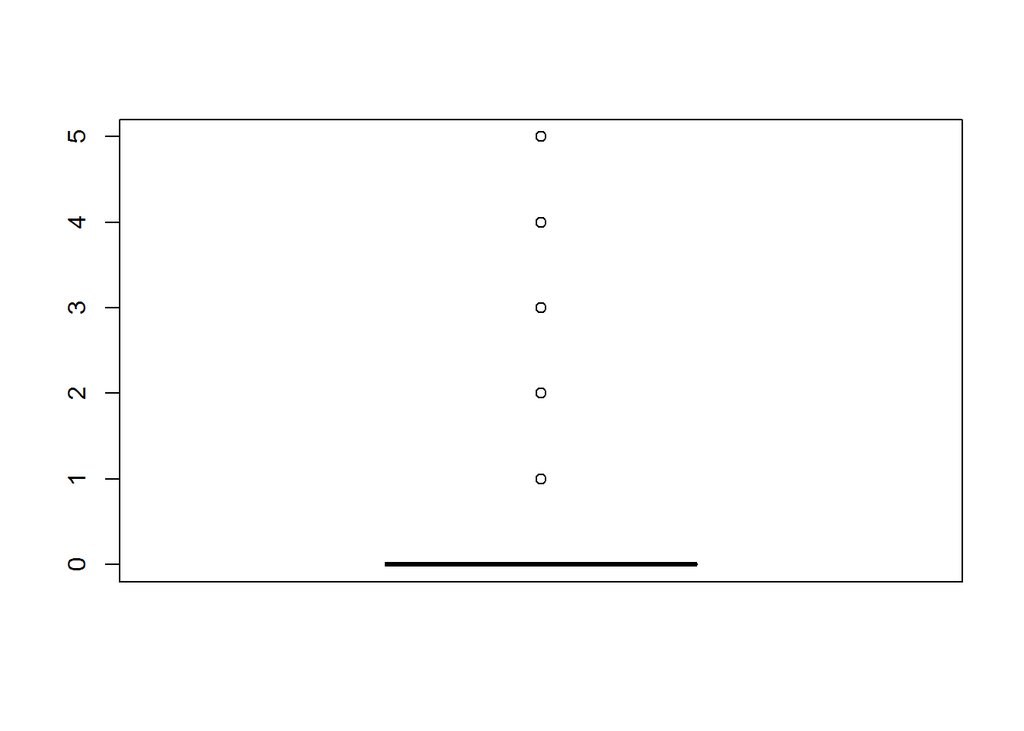

```r
boxplot(Terrorism_US_FIXED$nkillter)
```

Here, there is not a lot to comment. The only destacable thing would be that the majority of attackers are not killed during the attacks.

#### 2.20. Variable nwound

```r
summary(Terrorism_US_FIXED$nwound)
```

```
    Min.  1st Qu.   Median     Mean  3rd Qu.     Max.     NA's
   0.000    0.000    0.000    7.525    0.000 8191.000       93
```

```r
skewness(Terrorism_US_FIXED$nwound,na.rm = TRUE)
```

```
[1] 36.27749
```

```r
kurtosis(Terrorism_US_FIXED$nwound,na.rm = TRUE)
```

```
[1] 1329.347
```

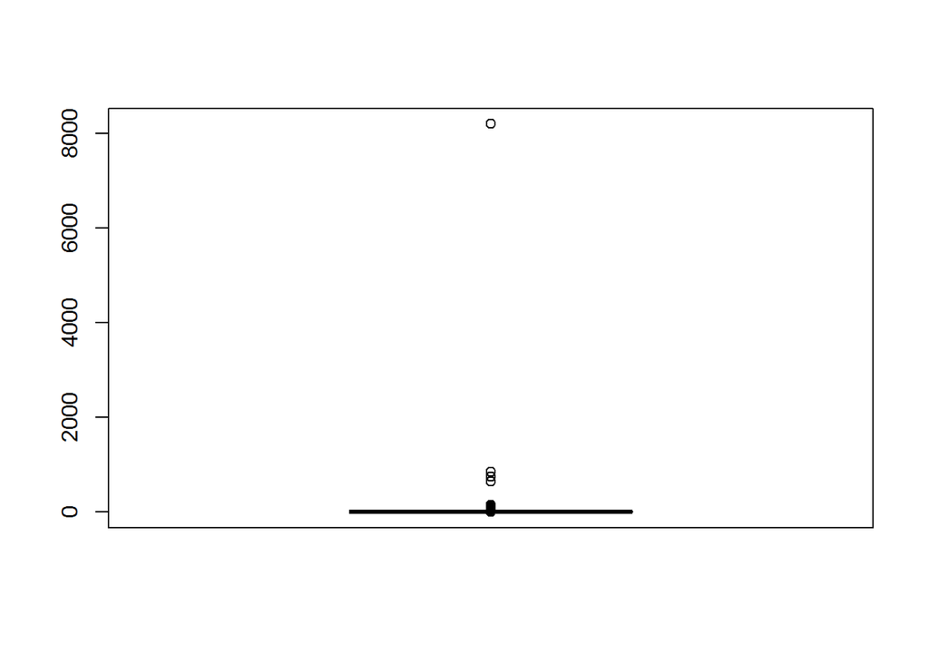

```r
boxplot(Terrorism_US_FIXED$nwound)
```

We can see a possible outlier that should be studied. We can also verify that most attacks do not cause injured people.

#### 2.21. Variable nwoundus

```r
summary(Terrorism_US_FIXED$nwoundus)
```

```
   Min. 1st Qu.  Median    Mean 3rd Qu.    Max.    NA's
  0.000   0.000   0.000   1.418   0.000 751.000     976
```

```r
skewness(Terrorism_US_FIXED$nwoundus,na.rm = TRUE)
```

```
[1] 28.7895
```

```r
kurtosis(Terrorism_US_FIXED$nwoundus,na.rm = TRUE)
```

```
[1] 860.6359
```

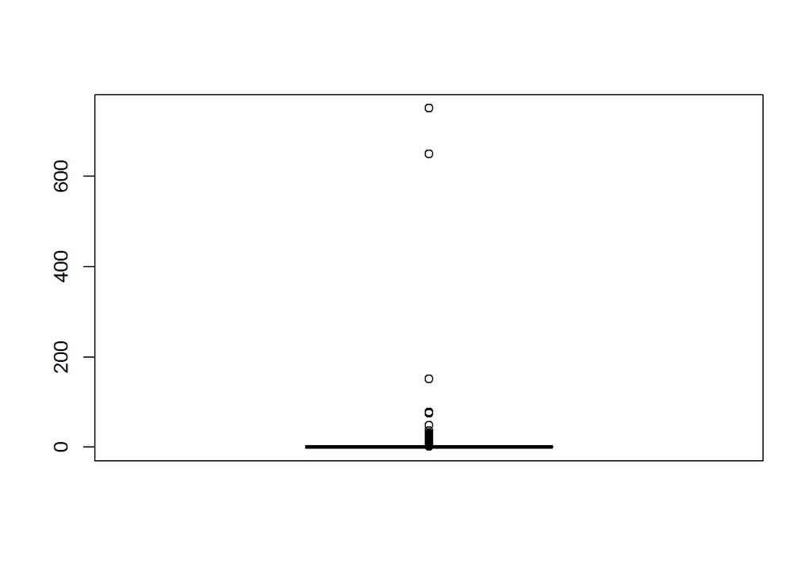

```r
boxplot(Terrorism_US_FIXED$nwoundus)
```

We can see a very similar chart to the previous one. We should study the relation between nwound and nwoundus in the future.

#### 2.22. Variable nwoundte

```r
summary(Terrorism_US_FIXED$nwoundte)
```

```
   Min. 1st Qu.  Median    Mean 3rd Qu.    Max.    NA's
 0.0000  0.0000  0.0000  0.0468  0.0000 36.0000    1018
```

```r
skewness(Terrorism_US_FIXED$nwoundte,na.rm = TRUE)
```

```
[1] 35.39434
```

```r
kurtosis(Terrorism_US_FIXED$nwoundte,na.rm = TRUE)
```

```
[1] 1366.975
```

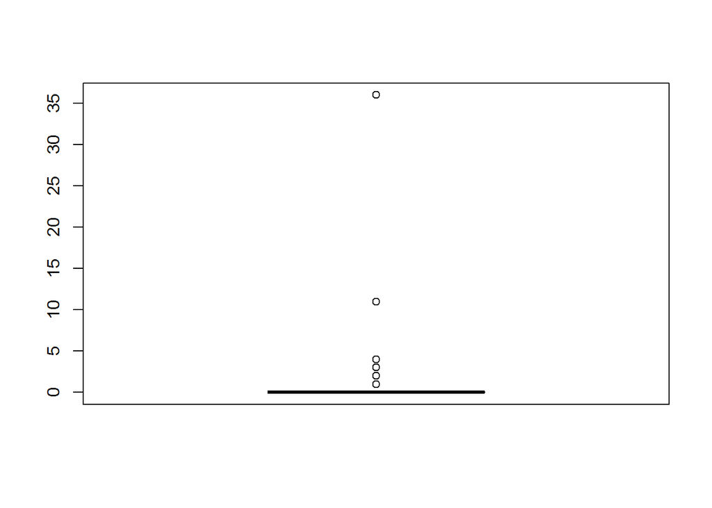

```r
boxplot(Terrorism_US_FIXED$nwoundte)
```

We can see that the majority of attackers are not injured during the attacks.

#### 2.23. Variable propvalue

```r
summary(as.numeric(Terrorism_US_FIXED$propvalue))
```

```
     Min.   1st Qu.    Median      Mean   3rd Qu.      Max.      NA's
      -99       -99      3850   1032156     60000 652000000      1882
```

```r
skewness(as.numeric(Terrorism_US_FIXED$propvalue,na.rm = TRUE))
```

```
[1] NA
```

```r
kurtosis(as.numeric(Terrorism_US_FIXED$propvalue,na.rm = TRUE))
```

```
[1] NA
```

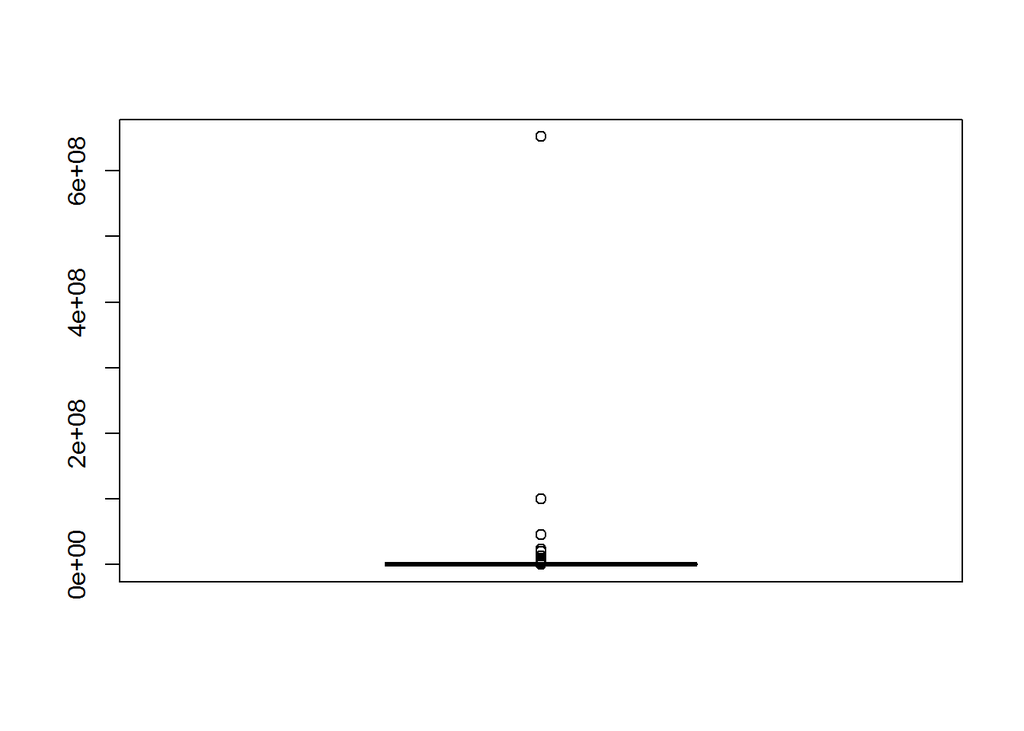

```r
boxplot(as.numeric(Terrorism_US_FIXED$propvalue))
```

As the data is not preprocessed yet, we can not extract conclusions but we can already see a possible outlier.

#### 2.24. Variable int_ideo

```r
summary(as.logical(Terrorism_US_FIXED$INT_IDEO))
```

```
   Mode    NA's
logical    2836
```

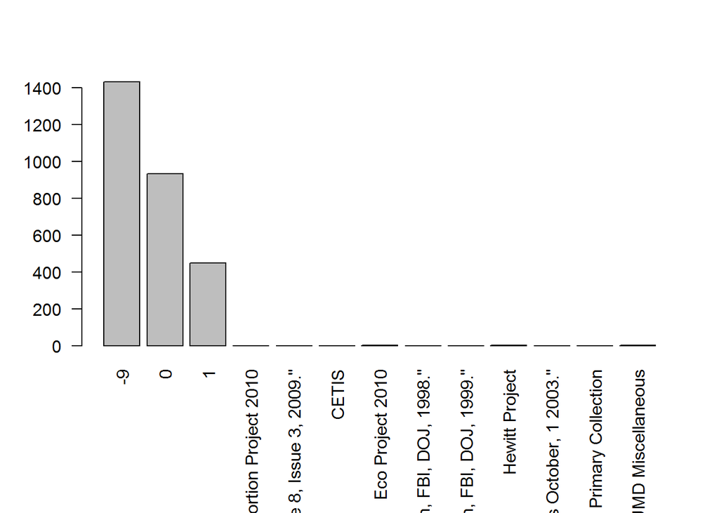

```r
op <- par(mar=c(8,4,4,2))
barplot(table(Terrorism_US_FIXED$INT_IDEO),las = 2)
```

```r
rm(op)
```

Thanks to this we see that for some reason despite being a logical variable there are many different values that do not make any sense, during the preprocessing we will study this.

#### 2.26. Variable int_misc

```r
summary(as.logical(Terrorism_US_FIXED$INT_MISC))
```

```
   Mode   FALSE    TRUE    NA's
logical    2387     445       4
```

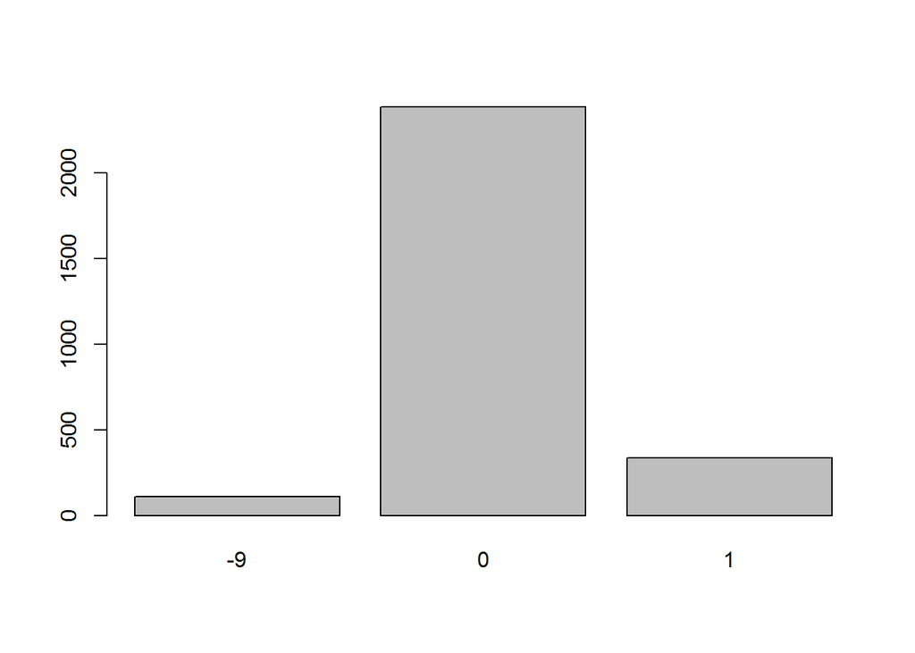

```r
barplot(table(Terrorism_US_FIXED$INT_MISC))
```

Because the missings in this variable are ‘-9’, R interpretes them as true because they are different than 0, so the summary does not count the number of trues correctly.

#### 2.27. Variable president_party

```r
summary(as.factor(Terrorism_US_FIXED$president_party))
```

```
Democratic Republican
       868       1968
```

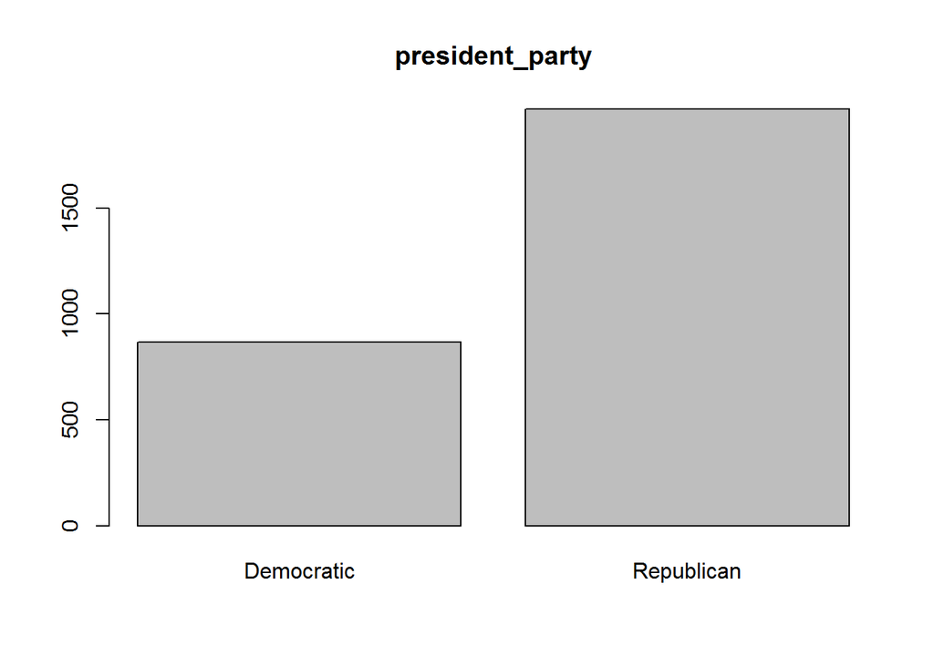

```r
barplot(table(Terrorism_US_FIXED$president_party),main="president_party")
```

This is a variable that seems correct.

#### 2.28. Variable state_governor_party

```r
summary(as.factor(Terrorism_US_FIXED$state_governor_party))
```

```
                                  Democrat
                                      1065
                     Democrat, Independent
                                         1
                      Democrat, Republican
                                       310
                                Democratic
                                         1
                   Democratic-Farmer-Labor
                                         2
                   Domecratic-Farmer-Labor
                                         6
                               Independent
                                         3
              Minnesota Independence Party
                                         3
                                       Nan
                                       223
                     New Progressive Party
                                       158
New Progressive Party of Puerto Rico (PNP)
                                         1
                  Popular Democratic Party
                                        89
                                Republican
                                       972
                                      NA's
                                         2
```

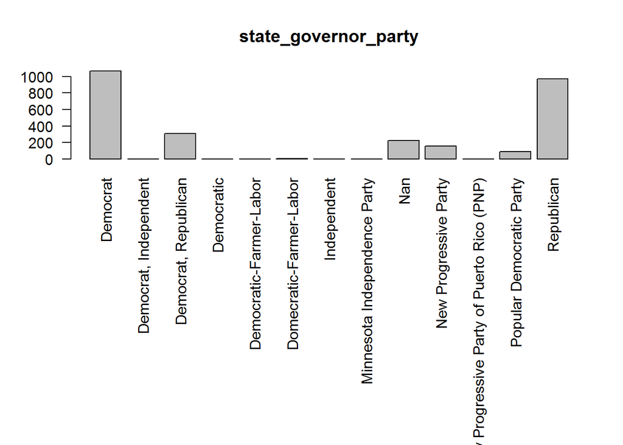

```r
op <- par(mar=c(16,4,4,2))

barplot(table(Terrorism_US_FIXED$state_governor_party),main="state_governor_party",las=2)
```

```r
rm(op)
```

In this summary we see that there are some typos, Democratic should probably be Democrat and Domecratic-Farmer-Labor should be Democratic-Farmer-Labor.